# Mapping SNPs to protein

Christopher Skopnik

2022-08-05

## Recommendations of how to improve this procedure are welcome.

```r
#install.packages("tidyverse")
#install.packages("rsnps")
#install.packages("rentrez")
#install.packages("pbapply")
#install.packages("protr")

#BiocManager::install("Biostrings")
#BiocManager::install("BSgenome.Hsapiens.UCSC.hg38")
#BiocManager::install("biomaRt")
#BiocManager::install("DECIPHER")
#BiocManager::install("ggmsa")

#install.packages("devtools")
#devtools::install_github("Close-your-eyes/igsc")

library(magrittr)

## FCMR (FC receptor for IgM, human); EntrezID: 9214
id <- 9214
```

Single nucleotide polymorphisms (snp) can be acquired from NCBI. They are mapped to genomic nucleotide positions. But how to map a snp to the corresponding position on protein level in order to find out its effect on the protein (e.g. silent mutation yes/no; premature stop codon induced yes/no, change to a similar aa or to one with very different chemical properties, etc.).  
Below snps within exons of FCMR (FAIM3, Toso), the human Fc receptor for IgM, are mapped to protein level and their effects are plotted in a multiple alignment.  
Data for FCMR are acquired manually and with biomaRt. The latter just to demonstrate that doing this job purely from R is feasible.

```r
## manual data acquisition from NCBI and UCSC
# this is always the plus-strand (gene for FCMR is on minus strand)
genome <- BSgenome.Hsapiens.UCSC.hg38::BSgenome.Hsapiens.UCSC.hg38
# gene boundaries from UCSC genome browser
fcmr_end_gen <- 206903317
fcmr_start_gen <- 206921941
# genomic
gen_man_plus <- Biostrings::DNAStringSet(stats::setNames(as.character(genome$chr1[fcmr_end_gen:fcmr_start_gen]), "gen_man_plus"))
gen_man_minus <- Biostrings::reverseComplement(gen_man_plus)
names(gen_man_minus) <- "gen_man_minus"
# exons
exons_man_minus <- Biostrings::DNAStringSet(unlist(protr::readFASTA("NM_005449.5.exons.fa")))
exons_man_plus <- Biostrings::reverseComplement(exons_man_minus)
# cds
cds_man_minus <- Biostrings::DNAStringSet(stats::setNames(protr::readFASTA("huFcmr.fasta")[[1]], "cds_man_minus"))
```

This kind of plotting is a sanity check to make sure that we know which sequences we have in our variables.

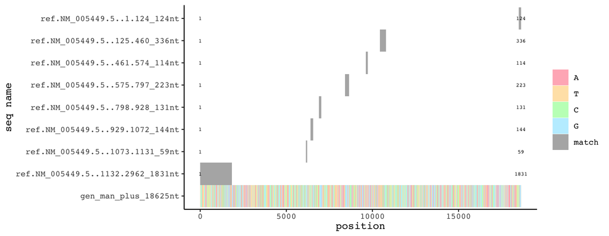

```r
igsc::MultiplePairwiseAlignmentsToOneSubject(subject = gen_man_plus,
                                             patterns = exons_man_plus,
                                             order.patterns = T,
                                             type = "local")[["match.plot"]]
```

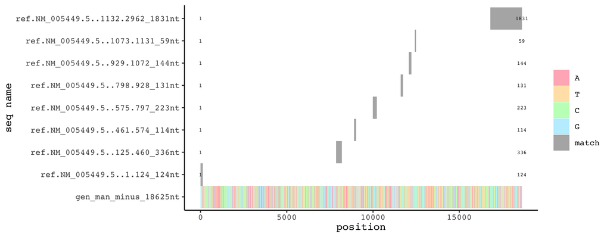

```r
igsc::MultiplePairwiseAlignmentsToOneSubject(subject = gen_man_minus,
                                             patterns = exons_man_minus,
                                             order.patterns = T,
                                             type = "local")[["match.plot"]]
```

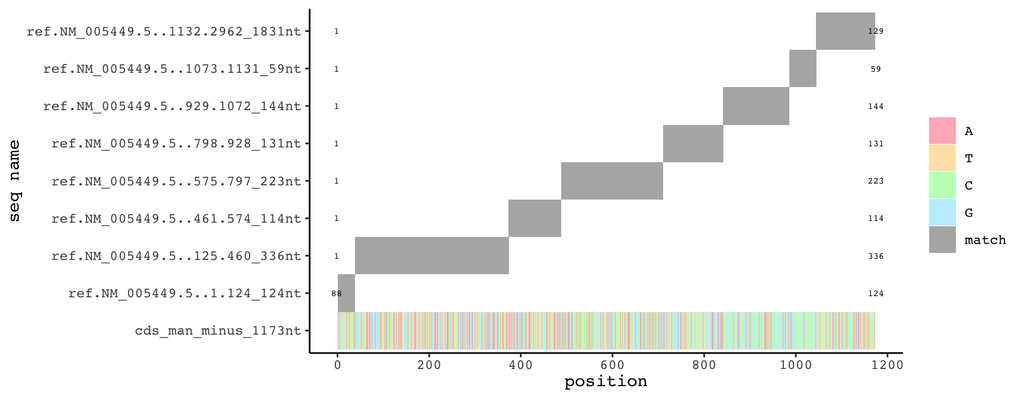

```r
igsc::MultiplePairwiseAlignmentsToOneSubject(subject = cds_man_minus,
                                             patterns = exons_man_minus,
                                             type = "local")[["match.plot"]]
```

```r
## data acquisition with bioMart
# same information in the end; just to demonstrate how to purely work from R
# queries for this FCMR (different isoforms are documented) only work without trailing .8 even though this is correct identifier at ensemble
# also choosing the 'correct' identifier (which is the desired isoform) was not trivial and had to be checked manually
# bioMart retrieves the gene information (cds; genomic; exons+introns) on the genes strand; in case of FCMR it is the minus strand
mart <- biomaRt::useMart("ensembl", dataset = "hsapiens_gene_ensembl")
# genomic
gen_mart_minus <-  biomaRt::getSequence(id = "ENST00000367091", #.8
                                        type = "ensembl_transcript_id",
                                        seqType = "gene_exon_intron",
                                        mart = mart)
gen_mart_minus <- Biostrings::DNAStringSet(stats::setNames(gen_mart_minus$gene_exon_intron, "gen_mart_minus"))
gen_mart_plus <- Biostrings::reverseComplement(gen_mart_minus)
names(gen_mart_plus) <- "gen_mart_plus"

# exons
exons_mart_minus_df <- biomaRt::getBM(attributes = c("gene_exon", "ensembl_exon_id", "exon_chrom_start", "exon_chrom_end"),
                                      filters = "ensembl_transcript_id",
                                      values = "ENST00000367091", #.8
                                      mart = mart)
exons_mart_minus_df <- exons_mart_minus_df[order(exons_mart_minus_df$exon_chrom_start, decreasing = TRUE),]
exons_mart_minus <- Biostrings::DNAStringSet(stats::setNames(exons_mart_minus_df$gene_exon, exons_mart_minus_df$ensembl_exon_id))
exons_mart_plus <- Biostrings::reverseComplement(exons_mart_minus)

# cds
cds_mart <- biomaRt::getSequence(id = "ENST00000367091", #.8
                                 type = "ensembl_transcript_id",
                                 seqType = "coding",
                                 mart = mart)
cds_mart <- Biostrings::DNAStringSet(stats::setNames(cds_mart$coding, "cds_mart"))
```

Again a sanity check.

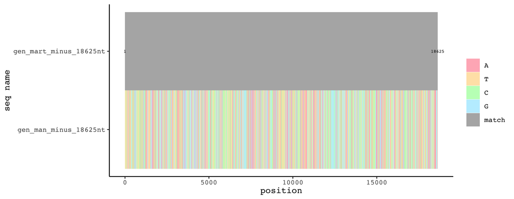

```r
# plot genomic seq from manual gathering and bioMart query against each other
igsc::MultiplePairwiseAlignmentsToOneSubject(subject = gen_man_minus,
                                             patterns = gen_mart_minus,
                                             type = "local")[["match.plot"]]
```

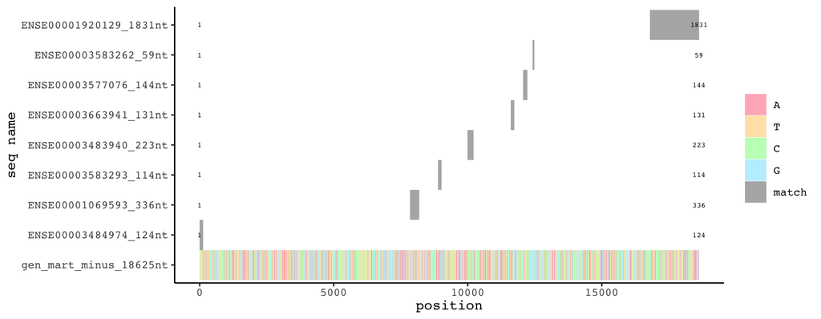

```r
# align exons against genomic seq and cds
igsc::MultiplePairwiseAlignmentsToOneSubject(subject = gen_mart_minus,
                                             patterns = exons_mart_minus,
                                             type = "local",
                                             order.patterns = T)[["match.plot"]]
```

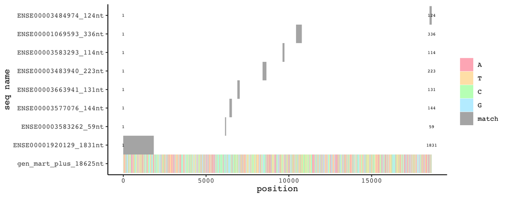

```r
igsc::MultiplePairwiseAlignmentsToOneSubject(subject = gen_mart_plus,
                                             patterns = exons_mart_plus,
                                             type = "local",
                                             order.patterns = T)[["match.plot"]]
```

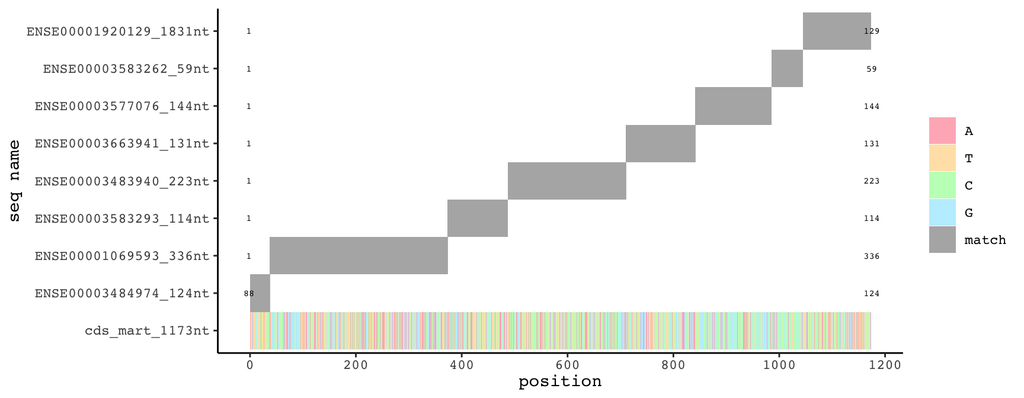

```r
igsc::MultiplePairwiseAlignmentsToOneSubject(subject = cds_mart,
                                             patterns = exons_mart_minus,
                                             type = "local",
                                             order.patterns = T)[["match.plot"]]
```

The pairwise alignments of exons against the genomic sequence allows us to map genomic snp position to mRNA levels and subsequently to protein level.

```r
# get genomic start and end positions for each exon by aligning exons to DNA minus strand
exon_in_genome <- purrr::map_df(.x = as.character(exons_man_minus), .id = "exon", .f = function(x) {
  pa <- Biostrings::pairwiseAlignment(subject = gen_man_minus,
                                      pattern = x,
                                      type = "local")
  data.frame(start_al = pa@subject@range@start,
             end_al = pa@subject@range@start + pa@subject@range@width - 1,
             start_genome = fcmr_start_gen - pa@subject@range@start + 1,
             end_genome = fcmr_start_gen - (pa@subject@range@start + pa@subject@range@width - 1) + 1)
})
exon_in_genome
```

```
##                         exon start_al end_al start_genome end_genome
## 1     ref|NM_005449.5|:1-124        1    124    206921941  206921818
## 2   ref|NM_005449.5|:125-460     7848   8183    206914094  206913759
## 3   ref|NM_005449.5|:461-574     8900   9013    206913042  206912929
## 4   ref|NM_005449.5|:575-797     9990  10212    206911952  206911730
## 5   ref|NM_005449.5|:798-928    11602  11732    206910340  206910210
## 6  ref|NM_005449.5|:929-1072    12074  12217    206909868  206909725
## 7 ref|NM_005449.5|:1073-1131    12422  12480    206909520  206909462
## 8 ref|NM_005449.5|:1132-2962    16795  18625    206905147  206903317
```

Acquisition of snp data from NCBI via R. This is probably also possible with biomaRt.

```r
# get snp identifiers from NCBI
snp_links <- rentrez::entrez_link(dbfrom = "gene", id = id, db = "snp")
fcmr_snps <- snp_links[["links"]][["gene_snp"]]

# get details for each snp
ncbi_snps <- parallel::mclapply(fcmr_snps, function(x) {
  tryCatch({
    # pulls from assembly 38
    rsnps::ncbi_snp_query(paste0("rs", x))
  }, error = function(e) {
    NULL
  })
}, mc.cores = 32)

#attr <- biomaRt::listAttributes(mart)
#marts <- biomaRt::listMarts()
#snps <- biomaRt::getBM( attributes=c("snp_chromosome_strand","chr_name","chrom_start"),filters=c("chr_name","chrom_start","chrom_end"), values=list(c(1),c(fcmr_start_gen), c(fcmr_end_gen)), mart)

# make a data frame; filter for snv* only; filter for snps within exons only
# *snv = single nucleotide variant
# https://stackoverflow.com/questions/15917233/elegant-way-to-vectorize-seq
seq2 <- Vectorize(seq.default, vectorize.args = c("from", "to"))
ncbi_snps_df <-
  dplyr::bind_rows(ncbi_snps) %>%
  dplyr::filter(bp %in% unlist(seq2(exon_in_genome[,"end_genome"], exon_in_genome[,"start_genome"]))) %>%
  dplyr::filter(class == "snv") %>%
  dplyr::arrange(-bp)
head(ncbi_snps_df,10)
```

```
## # A tibble: 10 × 16
##    query        chromosome        bp class rsid   gene  alleles ancestral_allele
##    <chr>        <chr>          <dbl> <chr> <chr>  <chr> <chr>   <chr>
##  1 rs1439264952 1          206921938 snv   rs143… FCMR  A,G,T   A
##  2 rs1022764050 1          206921936 snv   rs102… FCMR  C,T     C
##  3 rs910316155  1          206921935 snv   rs910… FCMR  A,C,G   A
##  4 rs984976444  1          206921932 snv   rs984… FCMR  T,C     T
##  5 rs951812176  1          206921921 snv   rs951… FCMR  C,T     C
##  6 rs1416546163 1          206921915 snv   rs141… FCMR  T,C     T
##  7 rs1026440563 1          206921912 snv   rs102… FCMR  C,T     C
##  8 rs1406373186 1          206921908 snv   rs140… FCMR  G,C     G
##  9 rs1356168468 1          206921907 snv   rs135… FCMR  A,C     A
## 10 rs1171552638 1          206921898 snv   rs117… FCMR  G,A     G
## # … with 8 more variables: variation_allele <chr>, seqname <chr>, hgvs <chr>,
## #   assembly <chr>, ref_seq <chr>, minor <chr>, maf <dbl>,
## #   maf_population <list>
```

Align coding sequence (cds) to exons to find its boundaries.

```r
# align cds to exons
# exons have more nts as they also comprise UTRs
# used alignment below to identify where cds starts
cds_exon_al <- Biostrings::pairwiseAlignment(pattern = cds_man_minus, subject = do.call(Biostrings::xscat, exons_man_minus), type = "local")
```

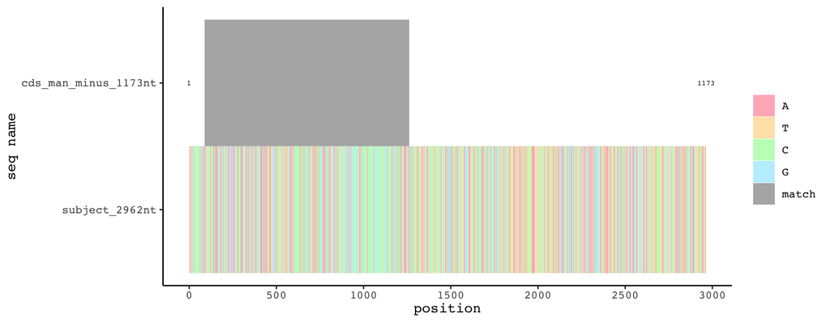

```r
igsc::MultiplePairwiseAlignmentsToOneSubject(patterns = cds_man_minus, subject = do.call(Biostrings::xscat, exons_man_minus), type = "local")[["match.plot"]]
```

```r
# create a data frame with one row for each exonic nucleotide
df_exon_gen_pos <- purrr::map_df(.x = names(exons_man_minus), .f = function(x) {
  data.frame(exon = x,
             nt = strsplit(as.character(exons_man_minus[[x]]), "")[[1]],
             gen_pos = exon_in_genome[which(exon_in_genome$exon == x), "start_genome"]:exon_in_genome[which(exon_in_genome$exon == x), "end_genome"])
}) %>%
  dplyr::mutate(row_num = dplyr::row_number()) %>%
  dplyr::mutate(cds = dplyr::between(row_num, cds_exon_al@subject@range@start, cds_exon_al@subject@range@start + cds_exon_al@subject@range@width - 1))
head(df_exon_gen_pos,10)
```

```
##                      exon nt   gen_pos row_num   cds
## 1  ref|NM_005449.5|:1-124  A 206921941       1 FALSE
## 2  ref|NM_005449.5|:1-124  G 206921940       2 FALSE
## 3  ref|NM_005449.5|:1-124  A 206921939       3 FALSE
## 4  ref|NM_005449.5|:1-124  T 206921938       4 FALSE
## 5  ref|NM_005449.5|:1-124  T 206921937       5 FALSE
## 6  ref|NM_005449.5|:1-124  G 206921936       6 FALSE
## 7  ref|NM_005449.5|:1-124  T 206921935       7 FALSE
## 8  ref|NM_005449.5|:1-124  G 206921934       8 FALSE
## 9  ref|NM_005449.5|:1-124  A 206921933       9 FALSE
## 10 ref|NM_005449.5|:1-124  A 206921932      10 FALSE
```

We just inspect snps within the first 30 aa of FCMR. This is totally arbitrary.

```r
# translate snps to their effect on protein level
range <- c(1:30) # arbitrary range of aa to consider below
fcmr_prot <- lapply(1:nrow(ncbi_snps_df), function(y) {
  bp <- ncbi_snps_df[y,"bp",drop=T]

  if (as.character(Biostrings::complement(Biostrings::DNAString(ncbi_snps_df[y,"ancestral_allele",drop=T]))) != df_exon_gen_pos[which(df_exon_gen_pos$gen_pos == bp),"nt",drop=T]) {
    # test if ancestral_allele from ncbi snp database matches the information in our data frame
    # turn ncbi info into complement as they come from plus strand, but FCMR is on minus strand
    stop("mismatch")
  }

  protein_with_snp <- lapply(strsplit(ncbi_snps_df[y,"variation_allele",drop=T], ",")[[1]], function(x) {
    df_exon_gen_pos[which(df_exon_gen_pos$gen_pos == bp),"nt"] <- as.character(Biostrings::complement(Biostrings::DNAString(x)))
    Biostrings::translate(Biostrings::DNAString(paste0(df_exon_gen_pos[which(df_exon_gen_pos$cds),"nt"], collapse = "")))[range]
  })
  names(protein_with_snp) <- rep(ncbi_snps_df[y,"rsid"], length(protein_with_snp))
  return(protein_with_snp)
})
names(fcmr_prot) <- ncbi_snps_df$rsid
fcmr_prot <- purrr::flatten(fcmr_prot)
# fcmr_prot is a list of protein sequences with modification according to the snp
# so one list entry for each snv-snp with exons
fcmr_prot[1:5]
```

```
## $rs1439264952
## 30-letter AAString object
## seq: MDFWLWPLYFLPVSGALRILPEVKVEGELG
##
## $rs1439264952
## 30-letter AAString object
## seq: MDFWLWPLYFLPVSGALRILPEVKVEGELG
##
## $rs1022764050
## 30-letter AAString object
## seq: MDFWLWPLYFLPVSGALRILPEVKVEGELG
##
## $rs910316155
## 30-letter AAString object
## seq: MDFWLWPLYFLPVSGALRILPEVKVEGELG
##
## $rs910316155
## 30-letter AAString object
## seq: MDFWLWPLYFLPVSGALRILPEVKVEGELG
```

```r
# exclude snps which cause a silent mutation
cds_aa_range <- Biostrings::translate(DNAStringSet(cds_man_minus))[[1]][range]
fcmr_prot2 <- lapply(fcmr_prot, function(x) {
  if (as.character(x) == as.character(cds_aa_range)) {
    return(NULL)
  } else {
    return(x)
  }
})
fcmr_prot2 <- fcmr_prot2[which(!sapply(fcmr_prot2, is.null))]

# add cds at the first index
fcmr_prot2 <- c(list(cds_aa_range), fcmr_prot2)
names(fcmr_prot2)[1] <- "cds"
```

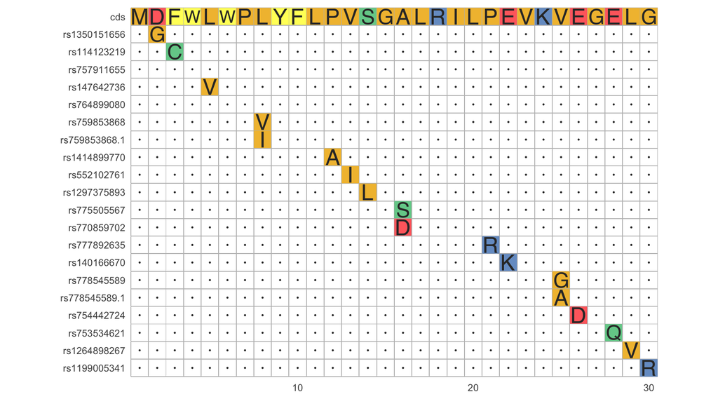

```r
# mutiple alignment of proteins with snps and plot
fcmr_prot2_mult_aln <- DECIPHER::AlignSeqs(Biostrings::AAStringSet(fcmr_prot2), verbose = F)
names(fcmr_prot2_mult_aln) <- make.unique(names(fcmr_prot2_mult_aln))

# print in easy-to-read-format like with printPairwiseAlignment
# http://emboss.sourceforge.net/docs/themes/AlignFormats.html

# or use DECIPHER (which opens the browser)
# DECIPHER::BrowseSeqs(fcmr_prot2_mult_aln, highlight = 1)

# or use ggmsa to get a ggplot2 object; note: stop-codons are plotted as empty positions (not so nice currently; DECIPHER plots asterisk (*))
ggmsa::ggmsa(msa = fcmr_prot2_mult_aln,
             seq_name = T,
             consensus_views = T,
             ref = "cds",
             use_dot = T)
```